# Project_Data_Anlytics

Bron_Luca, Grandadam_Patrik

06 November, 2018

**LE CODE EN COMMENTAIRE, C’EST JUSTE POUR POUVOIR KNIT PLUS VITE!!** (avec cache = TRUE, ca re-run pas le code, mais le markdown doit quand meme compiler les graphes, du coup ca prend du temps à chq fois…)

# Introduction

Parler de: - méthode utilisée - grandes étapes - classification task (goal) =/= prediction - [à compléter…]

–> Exploration des données = 1st insight –> Modelling: train/set set + selection du “meilleur” arbre(pruning)/svm(tuning)/NNET(nb of layers)/regression logicstic/K-NN(choisir K)/etc. + presentation de détail de tout ce bordel –> Cross validation avec les meilleurs de chq models pour selectionner le grand gagnant…

–> Description des variables (comme ca c’est plus simple de s’en sortir?!)

## Exploratory analysis

### Explanatory variables

Before beginning any kind of analysis, we have to understand the data we are working with.

Overview of our data

| variable | classe | first_values |
| --- | --- | --- |
| chk_acct | integer | 0, 1, 3, 0, 0, 3 |
| duration | integer | 6, 48, 12, 42, 24, 36 |
| history | integer | 4, 2, 4, 2, 3, 2 |
| new_car | integer | 0, 0, 0, 0, 1, 0 |
| used_car | integer | 0, 0, 0, 0, 0, 0 |
| furniture | integer | 0, 0, 0, 1, 0, 0 |
| radio.tv | integer | 1, 1, 0, 0, 0, 0 |
| education | integer | 0, 0, 1, 0, 0, 1 |
| retraining | integer | 0, 0, 0, 0, 0, 0 |
| amount | integer | 1169, 5951, 2096, 7882, 4870, 9055 |
| sav_acct | integer | 4, 0, 0, 0, 0, 4 |
| employment | integer | 4, 2, 3, 3, 2, 2 |
| install_rate | integer | 4, 2, 2, 2, 3, 2 |
| male_div | integer | 0, 0, 0, 0, 0, 0 |
| male_single | integer | 1, 0, 1, 1, 1, 1 |
| male_mar_or_wid | integer | 0, 0, 0, 0, 0, 0 |
| co.applicant | integer | 0, 0, 0, 0, 0, 0 |
| guarantor | integer | 0, 0, 0, 1, 0, 0 |
| present_resident | integer | 4, 2, 3, 4, 4, 4 |
| real_estate | integer | 1, 1, 1, 0, 0, 0 |
| prop_unkn_none | integer | 0, 0, 0, 0, 1, 1 |
| age | integer | 67, 22, 49, 45, 53, 35 |
| other_install | integer | 0, 0, 0, 0, 0, 0 |
| rent | integer | 0, 0, 0, 0, 0, 0 |
| own_res | integer | 1, 1, 1, 0, 0, 0 |
| num_credits | integer | 2, 1, 1, 1, 2, 1 |
| job | integer | 2, 2, 1, 2, 2, 1 |
| num_dependents | integer | 1, 1, 2, 2, 2, 2 |
| telephone | integer | 1, 0, 0, 0, 0, 1 |
| foreign | integer | 0, 0, 0, 0, 0, 0 |
| response | integer | good, bad, good, good, bad, good |

As we can see, the data are coherent with the infos that “the client” provided us. Most of them are binary of categorical, while only few are numerical.

More than seeing the first values of our variables and their types, we also need to understand how distributed they are and their link with each other. Thanks to a correlation plot, we can see the correlation between each pair of variable, but especially their correlation with our response variable in which we are interested in.  
We see for instances that variables like *chk_acct*, *duration*, *history*, *sav_accnt* or *rent* are highly correlated (positively or negatively) with our outcome variable and that they will be likeli to influe it in the models that we are going to plot. Others like *present_resident* or *retaining* should have low impact.

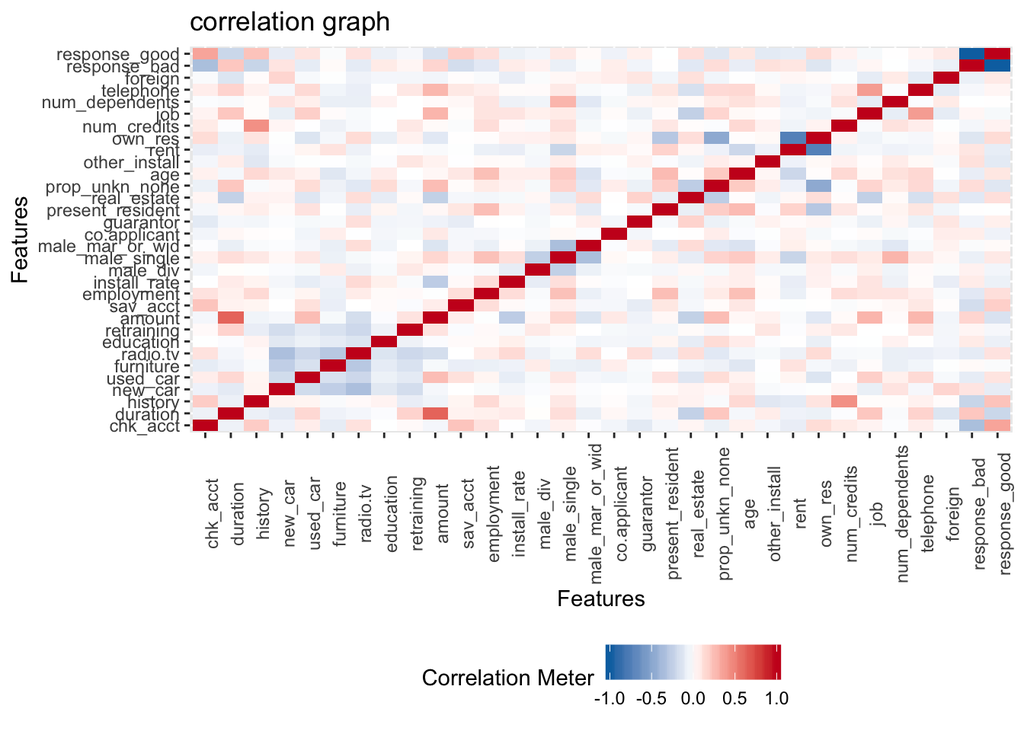

In addition, we can appreciate the summary of the different variables. The frequency table of *history* is presented below as an example:

Summary of variable history

|  | Value |
| --- | --- |
| Min. | 0.000 |
| 1st Qu. | 2.000 |
| Median | 2.000 |
| Mean | 2.545 |
| 3rd Qu. | 4.000 |
| Max. | 4.000 |

Frequency table of history

| Values | Frequency |
| --- | --- |
| 0 | 40 |
| 1 | 49 |
| 2 | 530 |
| 3 | 88 |
| 4 | 293 |

Thanks to these graphs, we can better understand our data at a glance and will be able to refer to them when needed.

Let’s first look at our variable *age*. We assume that, generally, a person will never live more than a hundred year, and will never contract a credit at such ages. This is why the data with $Age > 100$ are definitely wrong recorded. We will therefore have to replace them in our database.  
First, we have to find how much data are potentially dirty according to our assumptions and to localisate them in order to replace them.

Number of instances with age > 100

| Var1 | Freq |
| --- | --- |
| FALSE | 999 |
| TRUE | 1 |

Position of instance with age > 100

| x |
| --- |
| 537 |

According to our results, we have one data with $age > 100$ that has to be replaced. It is the instance 537 and its value is 125.

We can consider different options to replace this value. The first one could be to replace it by a value at random within the range (a value at random between 19 and 75, which is the second lowest value after $125$.  
However, according to the following histogram, the distribution of the age (without the erroneous data) is inequal with a concentration around small values.

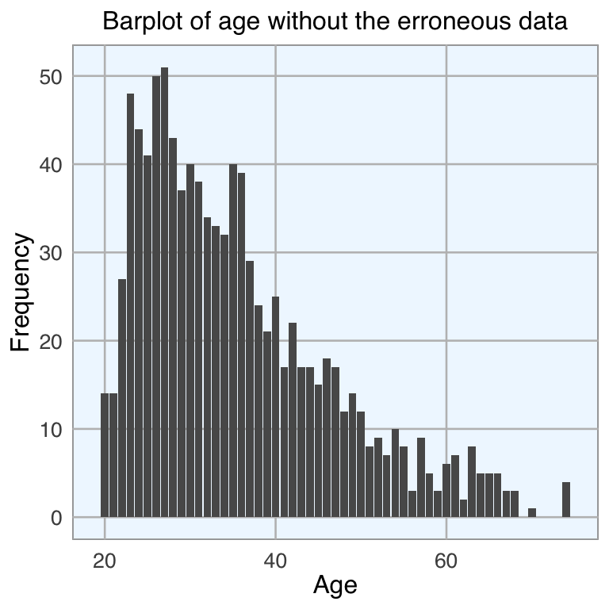

It could therefore be possible to replace it at random with different probabilities according to the size of each class.  
We prefer to opt for the median (equal to 33) to replace our problematic value as it offers more convenience.  
Note that for calculating the median, our problematic value should not be used.

An alternative could have been to use the mean, but, as we have no really big outlier, both values would have been close to eachother ($mean = 35.596$ while $median = 33$).

Next, we also have to deal with our two categorical data that have been wrong recorded:  
- one in *education*  
- one in *guarantor*

They also have to be cleaned.

The following is again the barplot of *education*.

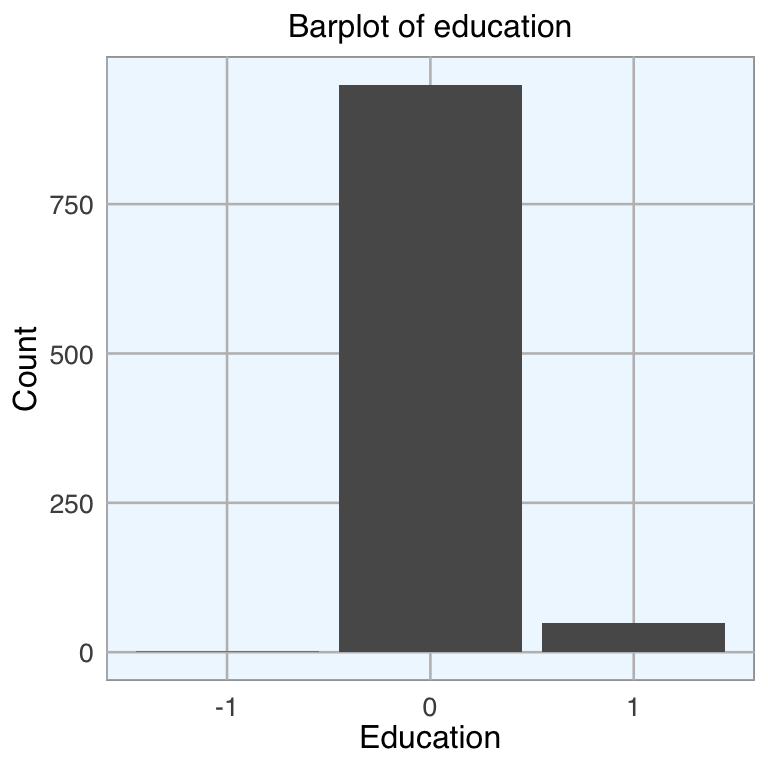

Here, the likelihood that this wrong recorded data is equal to $0$ is clearly higher. Therefore, each of the previously presented methods (using the mean, using the median and even assigning it to a class at random) would with a high probability result in assigning this instance and assign it the value $Education = 0$.  
We can confirm these first assumption with a frequency table:

Frequency table of education

|  | -1 | 0 | 1 |
| --- | --- | --- | --- |
| sample size | 1 | 950 | 49 |
| proportion | 0.1 % | 95 % | 4.9 % |

It is indeed more appropriate to replace our value by 0 as the probability of belonging to this class is close to 20 times bigger.

Concerning the variable *guarantor*, we can look at the frequency table and plot the barplot as well:

Frequency table of guarantor

|  | 0 | 1 | 2 |
| --- | --- | --- | --- |
| sample size | 948 | 51 | 1 |
| proportion | 94.8 % | 5.1 % | 0.1 % |

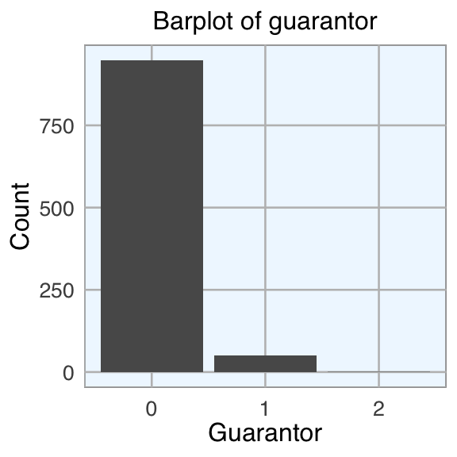

Again, for the same reasons, it is preferable to replace the wrong recorded data by 0.

In addition, the variable *present_resident* is also problematic as it doesn’t have the same range as the other categorical values. Its range goes from 1 to 4 whereas it should go from 0 to 3 like the other ones. We can modifiy its values in order to have the same format everywhere.

**Variable num_credits: y’a pas de 0, pas cohérent…**

These first steps have enabled us to better understand our explanatory variables and to clean the problematic ones.

### Response variable

As our final goal is to predict if a customer should be classified as a risky one or not, we have to have a particular look at our response variable that establishes if an applicant presents a good or a bad risk.

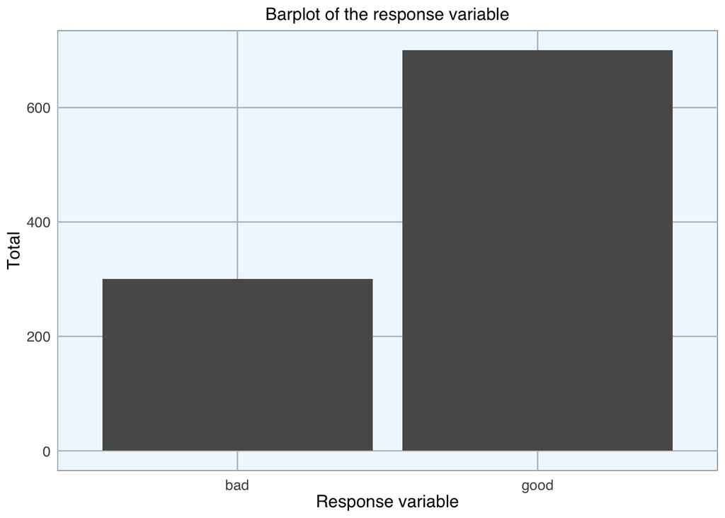

Frequency table of our response variable

|  | bad | good |
| --- | --- | --- |
| sample size | 300 | 700 |
| proportion | 30 % | 70 % |

We will get to this later. First, after having presented each variable, it could be interesting to see if we can already have some assumptions concerning the relations between the expanatory variables and the response variable.

### Interactions between the explanatory variables and the response variable

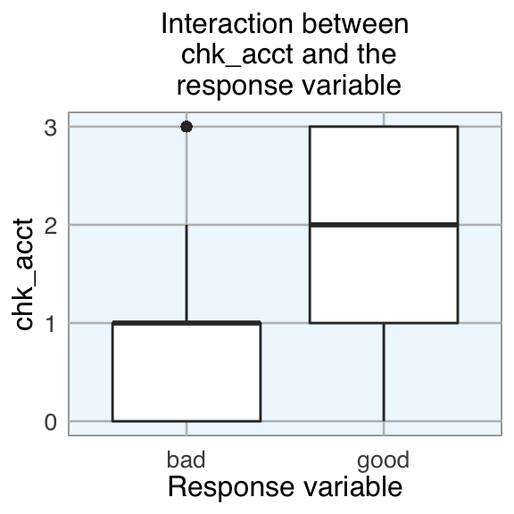

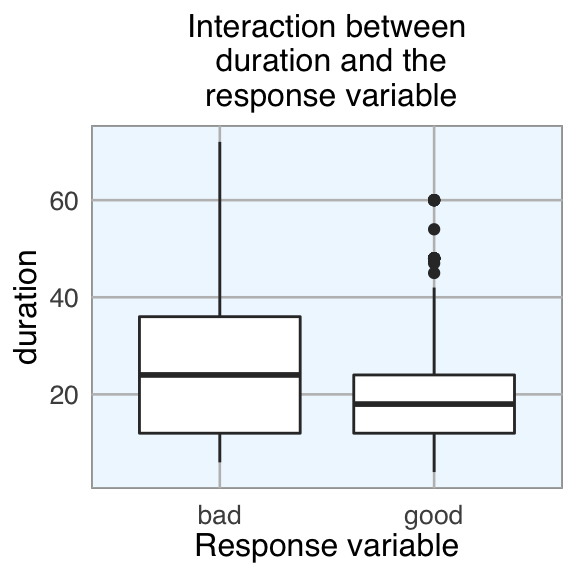

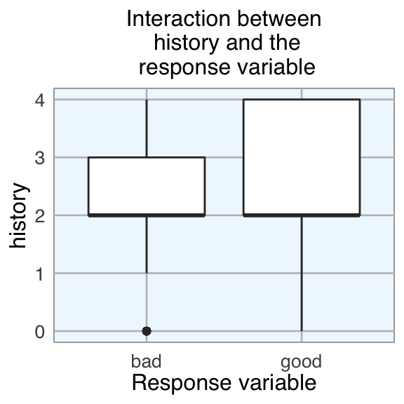

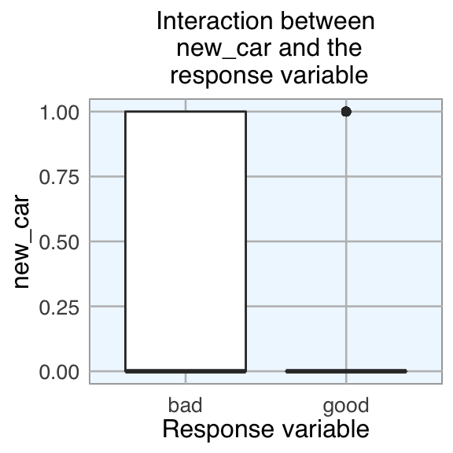

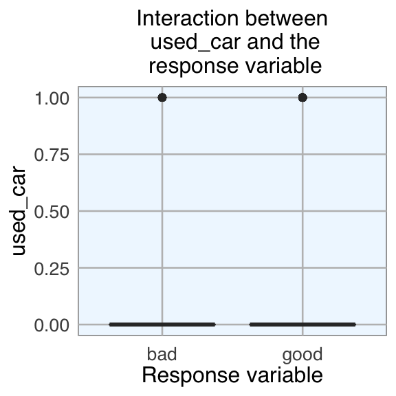

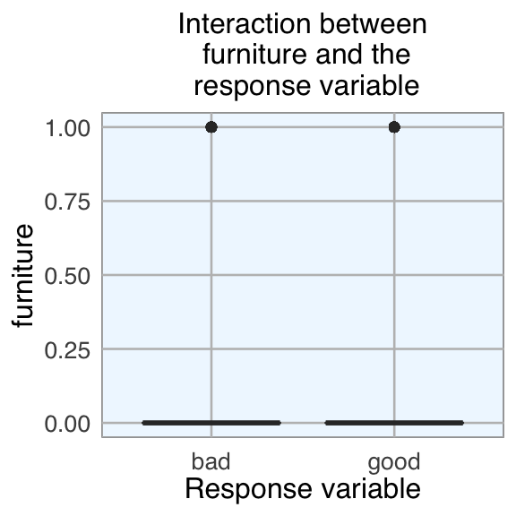

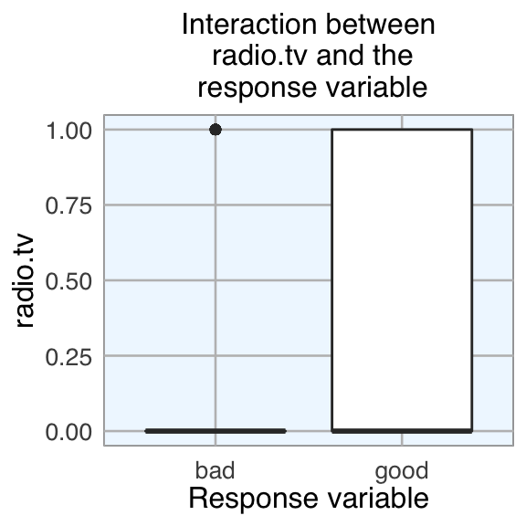

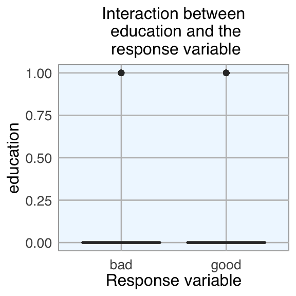

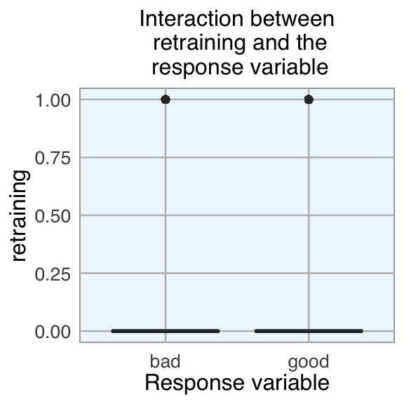

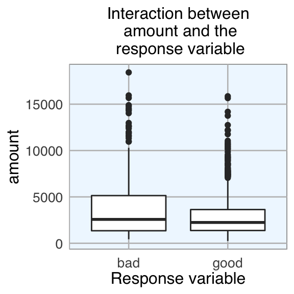

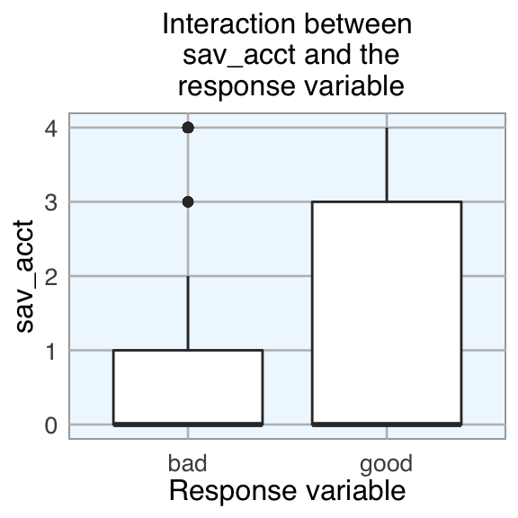

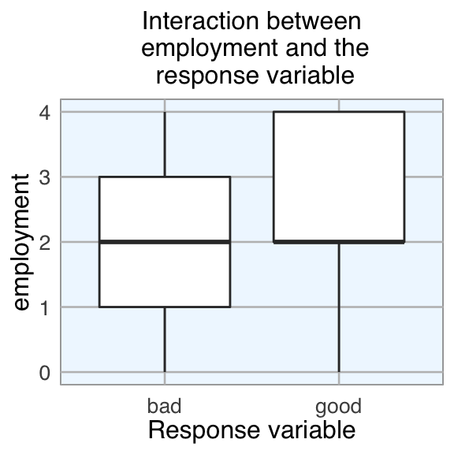

[18 more figures not shown]

–> Expliquer qu’on peut deja avoir un premier apriori sur les variables qui vont avoir un impact

# Modelling

Creation de test et train set:

## CART

** Petite description de CART, …**

### Building the model

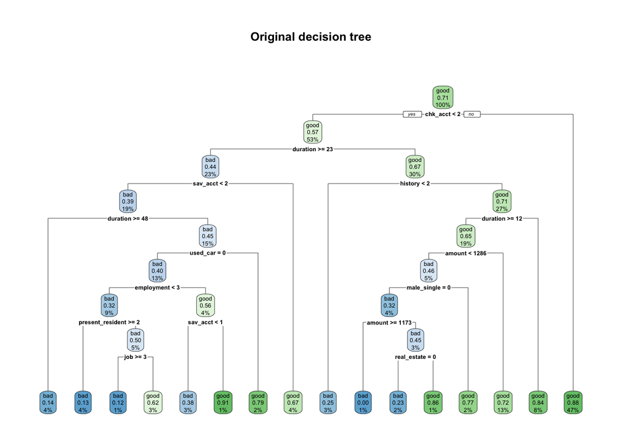

CP table of the CART model

| CP | nsplit | rel error | xerror | xstd |
| --- | --- | --- | --- | --- |
| 0.0511628 | 0 | 1.0000000 | 1.0000000 | 0.0576006 |
| 0.0465116 | 2 | 0.8976744 | 0.9906977 | 0.0574391 |
| 0.0186047 | 4 | 0.8046512 | 0.9348837 | 0.0564177 |
| 0.0155039 | 8 | 0.7255814 | 0.8976744 | 0.0556849 |
| 0.0139535 | 11 | 0.6790698 | 0.9023256 | 0.0557788 |
| 0.0116279 | 13 | 0.6511628 | 0.8790698 | 0.0553023 |
| 0.0100000 | 15 | 0.6279070 | 0.8744186 | 0.0552049 |

Variable importance table first 6 instances

|  | x |
| --- | --- |
| chk_acct | 36.917353 |
| duration | 18.425453 |
| sav_acct | 14.179762 |
| history | 12.668144 |
| amount | 12.035151 |
| age | 6.551922 |

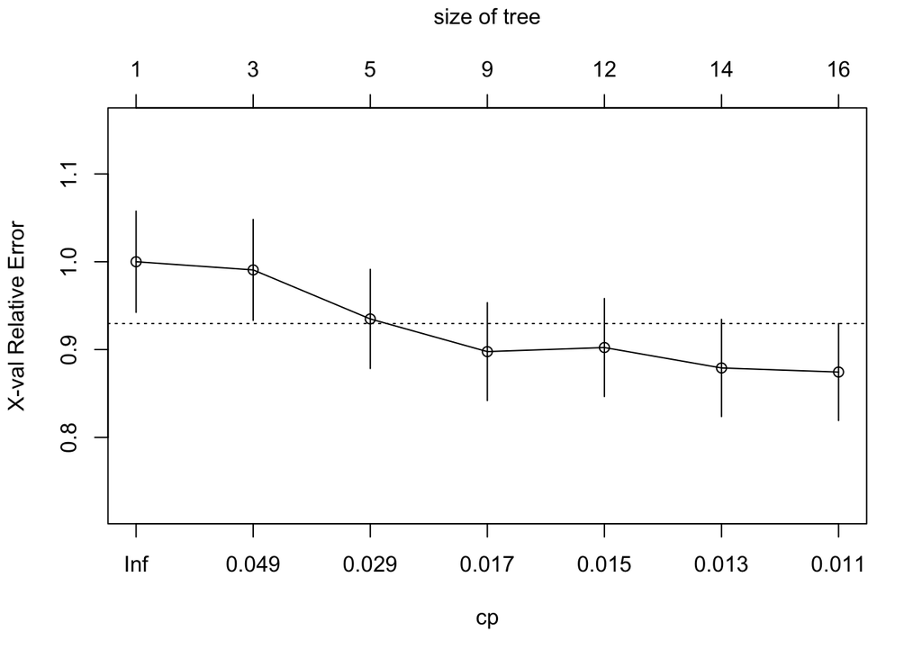

–> Bon model mais bcp trop complexe… On doit pruner. Idee: on veut un arbre plus simple sans perdre en qualité prédictive (on peut pas dire statistiquement que 1 est meilleur que l’autre etc.) –> Parler des variables les plus importantes

### Optimizing the model: Pruning

1 - SE rule… –> Parler de l’idée générale: simplifier le modele sans perdre en qualité –> Dire comment ca marche

Pruning the tree at CP = 0.0155039. According to our previous table, this represents 8 splits to be kept, equivalent to a tree of size 9.

CP table of the CART model

| CP | nsplit | rel error | xerror | xstd |
| --- | --- | --- | --- | --- |
| 0.0511628 | 0 | 1.0000000 | 1.0000000 | 0.0576006 |
| 0.0465116 | 2 | 0.8976744 | 0.9906977 | 0.0574391 |
| 0.0186047 | 4 | 0.8046512 | 0.9348837 | 0.0564177 |
| 0.0155039 | 8 | 0.7255814 | 0.8976744 | 0.0556849 |

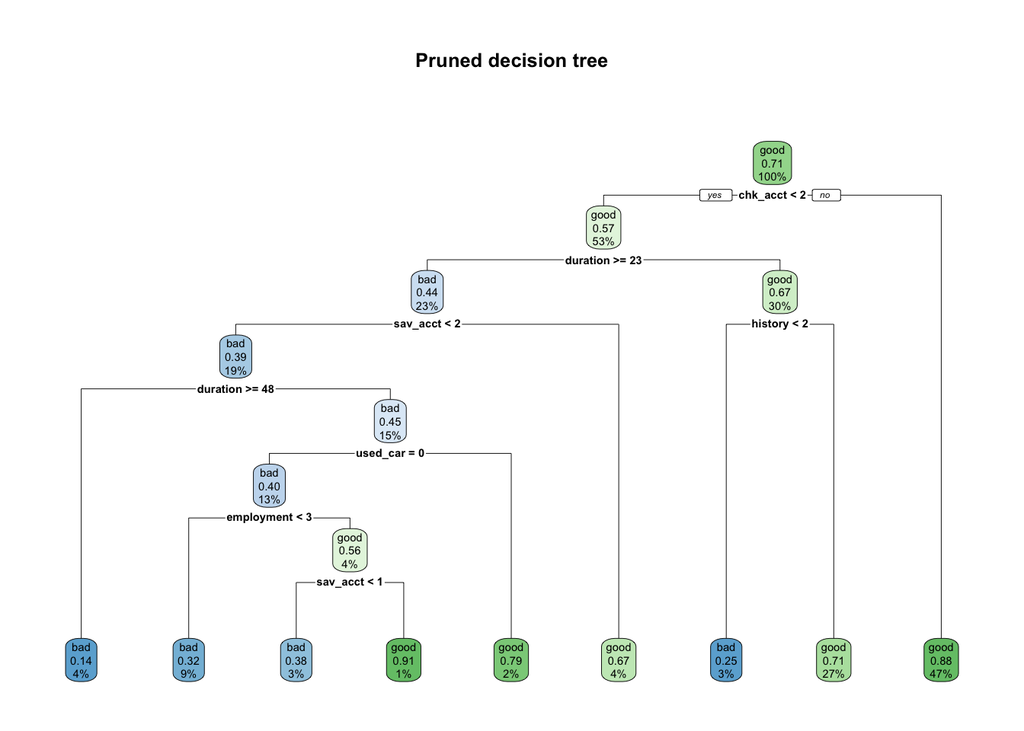

### Predicting the values of the testing set

Confusion matrix for the CART model

[output not shown]

Accuracy of the pruned CART model on the test set: 0.756.

More details:

```
   Cell Contents
|-------------------------|
|                       N |
|           N / Row Total |
|           N / Col Total |
|         N / Table Total |
|-------------------------|


Total Observations in Table:  250


                   | pred.cart
cred.test$response |       bad |      good | Row Total |
-------------------|-----------|-----------|-----------|
               bad |        36 |        49 |        85 |
                   |     0.424 |     0.576 |     0.340 |
                   |     0.750 |     0.243 |           |
                   |     0.144 |     0.196 |           |
-------------------|-----------|-----------|-----------|
              good |        12 |       153 |       165 |
                   |     0.073 |     0.927 |     0.660 |
                   |     0.250 |     0.757 |           |
                   |     0.048 |     0.612 |           |
-------------------|-----------|-----------|-----------|
      Column Total |        48 |       202 |       250 |
                   |     0.192 |     0.808 |           |
-------------------|-----------|-----------|-----------|
```

## Logistic regression

–> Parler de pourquoi Logistic regression (fait un bon taf quand outcome binaire)

### Building the model

```
Call:
glm(formula = response ~ ., family = "binomial", data = cred.train)

Deviance Residuals:
    Min       1Q   Median       3Q      Max
-2.6861  -0.6078   0.3580   0.6754   1.9238

Coefficients:
                   Estimate Std. Error z value Pr(>|z|)
(Intercept)       1.3358848  0.9904204   1.349 0.177399
chk_acct          0.5834664  0.0872800   6.685 2.31e-11 ***
duration         -0.0316908  0.0108378  -2.924 0.003455 **
history           0.3722442  0.1081812   3.441 0.000580 ***
new_car          -1.1537678  0.4711478  -2.449 0.014332 *
used_car          0.5111812  0.5832619   0.876 0.380803
furniture        -0.2370922  0.4867617  -0.487 0.626201
radio.tv         -0.3407874  0.4806207  -0.709 0.478289
education        -0.7110849  0.6251961  -1.137 0.255380
retraining       -0.4242103  0.5299820  -0.800 0.423465
amount           -0.0001221  0.0000531  -2.299 0.021494 *
sav_acct          0.2404315  0.0718614   3.346 0.000821 ***
employment        0.2063812  0.0887357   2.326 0.020029 *
install_rate     -0.3464544  0.1022160  -3.389 0.000700 ***
male_div         -0.6522849  0.4513532  -1.445 0.148408
male_single       0.6998022  0.2502476   2.796 0.005167 **
male_mar_or_wid   0.0852582  0.3483469   0.245 0.806649
co.applicant     -0.8683610  0.4446037  -1.953 0.050806 .
guarantor         0.6430509  0.4790109   1.342 0.179448
present_resident -0.0115307  0.1004384  -0.115 0.908601
real_estate       0.2529527  0.2452460   1.031 0.302342
prop_unkn_none   -0.5760071  0.4260875  -1.352 0.176423
age               0.0162805  0.0107570   1.513 0.130159
other_install    -0.6619041  0.2433515  -2.720 0.006529 **
rent             -0.4294464  0.5297871  -0.811 0.417594
own_res          -0.0236523  0.5035022  -0.047 0.962533
num_credits      -0.3758593  0.1998827  -1.880 0.060054 .
job               0.0208581  0.1648443   0.127 0.899311
num_dependents   -0.4231855  0.2916689  -1.451 0.146805
telephone         0.3114322  0.2347207   1.327 0.184568
foreign           1.8095833  0.8172659   2.214 0.026816 *
---
Signif. codes:  0 '***' 0.001 '**' 0.01 '*' 0.05 '.' 0.1 ' ' 1

(Dispersion parameter for binomial family taken to be 1)

    Null deviance: 898.71  on 749  degrees of freedom
Residual deviance: 647.07  on 719  degrees of freedom
AIC: 709.07

Number of Fisher Scoring iterations: 5
```

–> Parler du fait qu’on a des similitudes avec CART (les variables importantes avant ont aussi des coeffs signi ici… ** pas toutes… ** –> nuancer…). –> Parler du fait qu’on a aussi plein de variables inutiles et qu’on va faire une stepwise pour minimiser AIC –> Dire l’idée de AIC (arbritrage entre perf du model et complexité) –> Expliquer comment ca marche

### Optimizing the model: Stepwise selection according to AIC criteria

```r
logit.step <- step(logit.model, direction="both")
summary(logit.step)
```

[output not shown]

–> Parler du fait qu’on a quand meme encore énormément de variables mais que le AIC est minimisé –> Parler du fait qu’on pourrait en virer manuellement (mais long et chiant)

### Predicting the values of the testing set

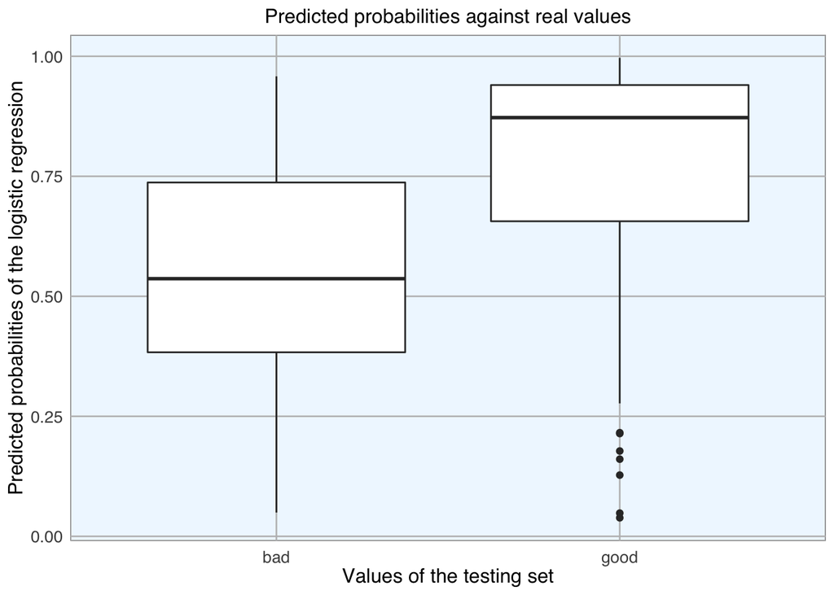

Confusion matrix for the Logistic regression model

|  | Predict 0 | Predict 1 |
| --- | --- | --- |
| bad | 38 | 47 |
| good | 19 | 146 |

```
   Cell Contents
|-------------------------|
|                       N |
|           N / Row Total |
|           N / Col Total |
|         N / Table Total |
|-------------------------|


Total Observations in Table:  250


                   | pred.logit.step
cred.test$response |       bad |      good | Row Total |
-------------------|-----------|-----------|-----------|
               bad |        38 |        47 |        85 |
                   |     0.447 |     0.553 |     0.340 |
                   |     0.667 |     0.244 |           |
                   |     0.152 |     0.188 |           |
-------------------|-----------|-----------|-----------|
              good |        19 |       146 |       165 |
                   |     0.115 |     0.885 |     0.660 |
                   |     0.333 |     0.756 |           |
                   |     0.076 |     0.584 |           |
-------------------|-----------|-----------|-----------|
      Column Total |        57 |       193 |       250 |
                   |     0.228 |     0.772 |           |
-------------------|-----------|-----------|-----------|
```

FALSE POSITIVE: 47 sur les 250 sont prédits 1 alors qu’ils sont 0… C’est la merde Idée: on peut changer la proba limite pour dire que c’est “bon” pour avoir moins de FALSE POSITIVE… Ca va baisser l’accuracy, mais ca va potentiellement nous faire perdre moins d’argent (on va refuser plus souvent les crédits à risques, et aussi les crédits sans risques…)

Confusion matrix for the adapted Logistic regression model

|  | Predict bad | Predict good |
| --- | --- | --- |
| bad | 64 | 21 |
| good | 55 | 110 |

```
## [1] 0.696
```

–> En passant la limite à 0.75, on a gardé une bonne accuracy, et on fait moins d’erreurs d’évaluation parmis les “risky”. Faut voir se que la banque peut se permettre comme marge et si les risky conduisent forcément à des pertes…

## Neural Network

### Building the model and optimizing it: selecting the number of neurones in the hidden layer

La “littérature” (https://stats.stackexchange.com/questions/181/how-to-choose-the-number-of-hidden-layers-and-nodes-in-a-feedforward-neural-netw) suggère de garder 1 seul layer un nb de neuronnes entre 1 et le nbr de dim: on va les tester tous et garder le meilleur… “In sum, for most problems, one could probably get decent performance (even without a second optimization step) by setting the hidden layer configuration using just two rules: (i) number of hidden layers equals one; and (ii) the number of neurons in that layer is the mean of the neurons in the input and output layers.”

After having created different models with a different number of neurons in the hidden layers, we have to be able to access the created models and to select the best one based on it.

## Support Vector Machine (SVM)

### Optimizing the model: selecting good cost and gamma parameters

### Predicting the values of the testing set

## Model x (K-nn)

### Building the model

```
[1] "The selected knn model uses a distance of 2 and is computed with the 13 neerest neighbors. The obtained accuracy is equal to 0.712"
```

Confusion matrix of the fitted KNN model

[output not shown]

Petit DB donc pas un pb que “lazy learner”

### Optimizing the model: selecting the number of nodes and layers

### Predicting the values of the testing set

Apres y’en a marre…

# Cross Validation approach

Creation of 10 different sets in order to do the Cross-Validation. The number of instances being 1000, we will make 10 sets of size 100. They are stored in a list named test.list. At each step, the remaining part of the data base is stored in the list train.test.